# FE8828 Assignment 4 for Exploratory Data Analysis with ggplot2

Wei Kuang <sub><Email:kwan0067@e.ntu.edu.sg></sub>

Oct 2019

# Information

In this study, we examine the dataset: bank to derive 10 data insights. Below provides descriptions for each variable.

#### Personal profile:

1. **age** (numeric)
2. **job** : type of job (categorical: “admin.”,“unknown”,“unemployed”,“management”,“housemaid”,“entrepreneur”,“student”, “blue-collar”,“self-employed”,“retired”,“technician”,“services”)
3. **marital** : marital status (categorical: “married”,“divorced”,“single”; note: “divorced” means divorced or widowed)
4. **education** (categorical: “unknown”,“secondary”,“primary”,“tertiary”)
5. **default**: has credit in default? (binary: “yes”,“no”)
6. **balance**: average yearly balance, in euros (numeric)
7. **housing**: has housing loan? (binary: “yes”,“no”)
8. **loan**: has personal loan? (binary: “yes”,“no”)

#### Related with the last contact of the current campaign:

9. **contact**: contact communication type (categorical: “unknown”,“telephone”,“cellular”)
10. **day**: last contact day of the month (numeric)
11. **month**: last contact month of year (categorical: “jan”, “feb”, “mar”, …, “nov”, “dec”)
12. **duration**: last contact duration, in seconds (numeric)

#### Other attributes:

13. **campaign**: number of contacts performed during this campaign and for this client (numeric, includes last contact)
14. **pdays**: number of days that passed by after the client was last contacted from a previous campaign (numeric, -1 means client was not previously contacted)
15. **previous**: number of contacts performed before this campaign and for this client (numeric)
16. **poutcome**: outcome of the previous marketing campaign (categorical: “unknown”,“other”,“failure”,“success”)

#### Output variable (desired target):

17. **y** - has the client subscribed a term deposit? (binary: “yes”,“no”)

Also, for below analysis, derived variable: **age_group** refers to

| age_group | Age range |
| --- | --- |
| 10 | 10,19 |
| 20 | 20,29 |
| 30 | 30,39 |
| 40 | 40,49 |
| 50 | 50,59 |
| 60 | 60,69 |
| 70 | 70,79 |
| 80 | 80,89 |

also, derived variable: **working** refers to

| working | job |
| --- | --- |
| no | unknown |
| no | unemployed |
| no | housemaid |
| no | student |
| no | retired |
| yes | admin |
| yes | management |
| yes | entrepreneur |
| yes | blue-collar |
| yes | self-employed |
| yes | technician |
| yes | services |

# Finding #1

#### How balance trends with age for working/non-working clients.

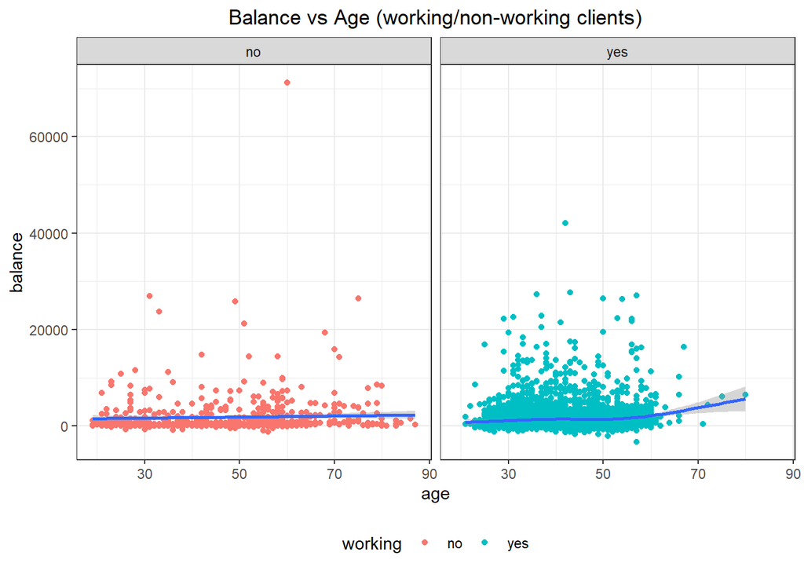

```r
df <- mutate(bank, working = ifelse(job %in% c("unknown", "unemployed", "housemaid", "student", "retired"), "no", "yes"), age_group = (age %/% 10) * 10)

ggplot(df, aes(age, balance)) +
  geom_point(aes(color = working)) +
  geom_smooth() +
  theme_bw() +
  facet_grid(. ~ working) +
  theme(legend.position = "bottom") +
  labs(title = "Balance vs Age (working/non-working clients)") +
  theme(plot.title = element_text(hjust = 0.5))
## `geom_smooth()` using method = 'gam' and formula 'y ~ s(x, bs = "cs")'
```

For working client, the **average yearly balance increases as age increases, while for non-working clients, average yearly balance remains rather muted as age increases**.

# Finding #2

#### Study of age profile of those default/no default, breakdown by working/non-working.

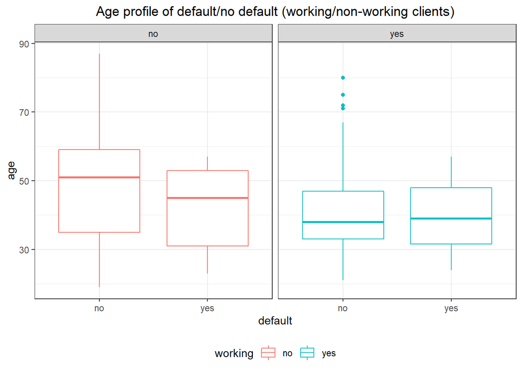

```r
ggplot(df, aes(default, age)) +
  geom_boxplot(aes(color = working)) +
  theme_bw() +
  facet_grid(. ~ working) +
  theme(legend.position = "bottom") +
  labs(title = "Age profile of default/no default (working/non-working clients)") +
  theme(plot.title = element_text(hjust = 0.5))
```

**For non-working clients, the median age is higher for those not having credit in default than those having credit in default**.

On the other hand, **for working clients, the median age is slightly lower for those not having credit in default than those having credit in default**.

# Finding #3

#### Study of age group with respect to the proportion of default.

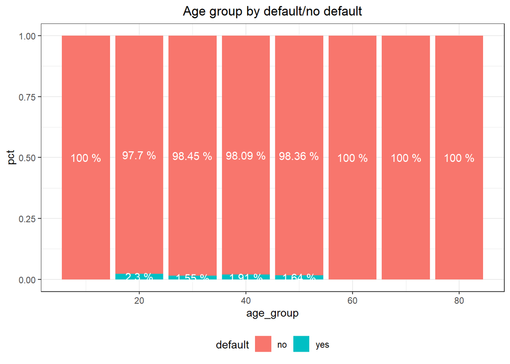

```r
df2 <- df %>% group_by(age_group, default) %>% summarise(count = n())
df3 <- df %>% group_by(age_group) %>% summarise(tot = n())
df2 <- left_join(df2, df3, by = "age_group") %>% mutate(pct = count/tot*100)

ggplot(df2, mapping = aes(age_group, pct, fill = default)) +
  geom_bar(position = "fill", stat = "identity") +
  geom_text(aes(label = paste(round(pct,2), "%")),
        position = position_fill(vjust = 0.5),
        color = "white") +
  theme_bw() +
  theme(legend.position = "bottom") +
  labs(title = "Age group by default/no default") +
  theme(plot.title = element_text(hjust = 0.5))
```

It is again shown that only age range from 20 to 60 has credit in default. Of which, **age range from 20 to 30 has the highest proportion of default at 2.3%**.

# Finding #4

#### Study of job breakdown by marital status (sorted in descending order of mean balance).

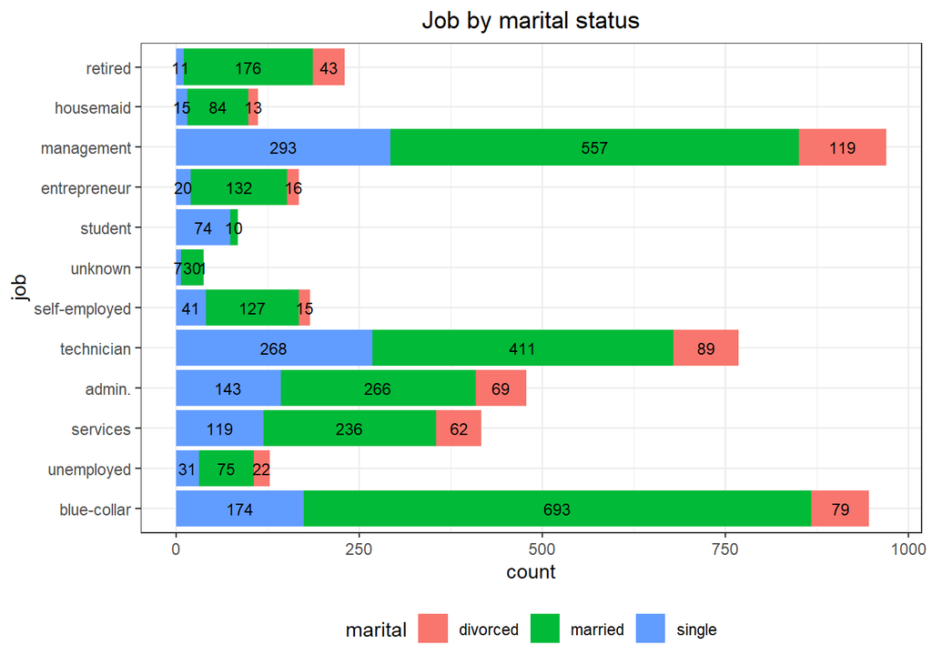

```r
df4 <- df %>% group_by(job, marital) %>% summarise(count = n())
df5 <- df %>% group_by(job) %>% summarise(meanBal = mean(balance))
df4 <- left_join(df4, df5, by = "job")

ggplot(df4, mapping = aes(x = reorder(job, meanBal, FUN = mean), y = count, fill = marital, label = count)) +
  geom_bar(stat = "identity") +
  geom_text(size = 3, position = position_stack(vjust = 0.5)) +
  coord_flip()+
  theme_bw() +
  theme(legend.position = "bottom") +
  labs(title = "Job by marital status") +
  labs(x = "job") +
  theme(plot.title = element_text(hjust = 0.5))
```

```r
df5 %>% arrange(desc(meanBal))
```

```
## # A tibble: 12 x 2
##    job           meanBal
##    <fct>           <dbl>
##  1 retired         2319.
##  2 housemaid       2084.
##  3 management      1767.
##  4 entrepreneur    1645.
##  5 student         1544.
##  6 unknown         1502.
##  7 self-employed   1392.
##  8 technician      1331.
##  9 admin.          1227.
## 10 services        1104.
## 11 unemployed      1089.
## 12 blue-collar     1085.
```

**Retired clients**, made up of 11 singles, 176 married and 43 divorced **has the highest mean balance of 2319**.

The highest number of clients are in the management role (total count = 969) and has a mean balance of 1767.

# Finding #5

### Study of number of days passed since last contact, breakdown by working/non-working (for clients who have been previously contacted).

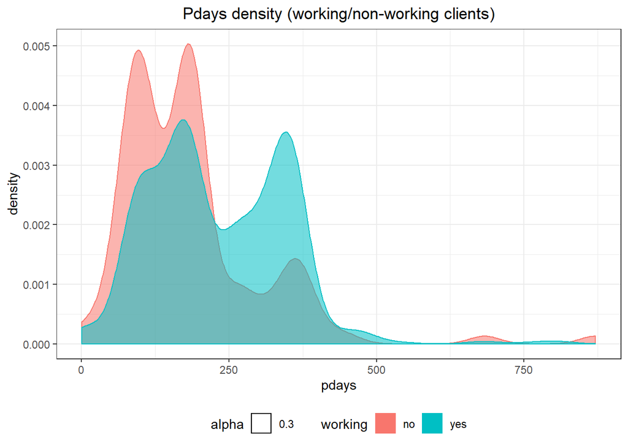

```r
ggplot(dplyr::filter(df, pdays != -1), aes(pdays, color = working, fill = working, alpha = 0.3)) +
  geom_density()+
  theme_bw() +
  theme(legend.position = "bottom") +
  labs(title = "Pdays density (working/non-working clients)") +
  theme(plot.title = element_text(hjust = 0.5))
```

There are **two peak pdays observed for both working and non-working clients**. Pdays for working clients are generally longer than that of non-working clients.

# Finding #6

### Study of age profile of those clients who subscribed term deposits, breakdown by working/non-working and education.

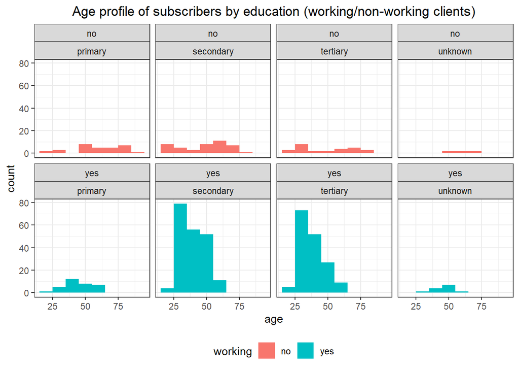

```r
ggplot(dplyr::filter(df, y == "yes"), aes(age, fill = working)) +
  geom_histogram(binwidth=10) +
  facet_wrap(working ~ education, nrow = 2) +
  theme_bw() +
  theme(legend.position = "bottom") +
  labs(title = "Age profile of subscribers by education (working/non-working clients)") +
  theme(plot.title = element_text(hjust = 0.5))
```

Most of those subscribed are working clients. **Working clients with education = “secondary” and “tertiary” are the two highest count groups**, with **majority of them in age range from around 25 to around 50**.

# Finding #7

### How different are the loan profiles of clients in management role vs clients who retired?

Note that having loan means having either housing loan or personal loan or both.

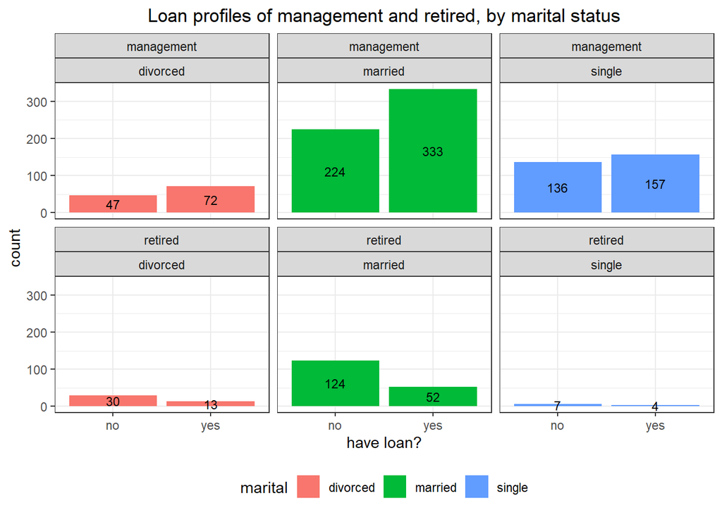

```r
df6 <- dplyr::filter(df, job %in% c("management","retired")) %>%
  mutate(have_loan = case_when(
    housing == "yes" | loan == "yes" ~ "yes",
    TRUE ~ "no"
    )) %>%
  group_by(job, marital, have_loan) %>%
  summarise(count = n())

ggplot(df6, mapping = aes(x = have_loan, y = count, fill = marital, label = count)) +
  geom_bar(stat = "identity") +
  geom_text(size = 3, position = position_stack(vjust = 0.5)) +
  facet_wrap(job ~ marital, nrow = 2) +
  theme_bw() +
  theme(legend.position = "bottom") +
  labs(title = "Loan profiles of management and retired, by marital status") +
  labs(x = "have loan?") +
  theme(plot.title = element_text(hjust = 0.5))
```

**Majority of the clients in management role have loans, but not clients who retired**. In both management and retired, married clients are the largest groups.

# Finding #8

### Study of duration density by contact communication type (telephone, cellular)

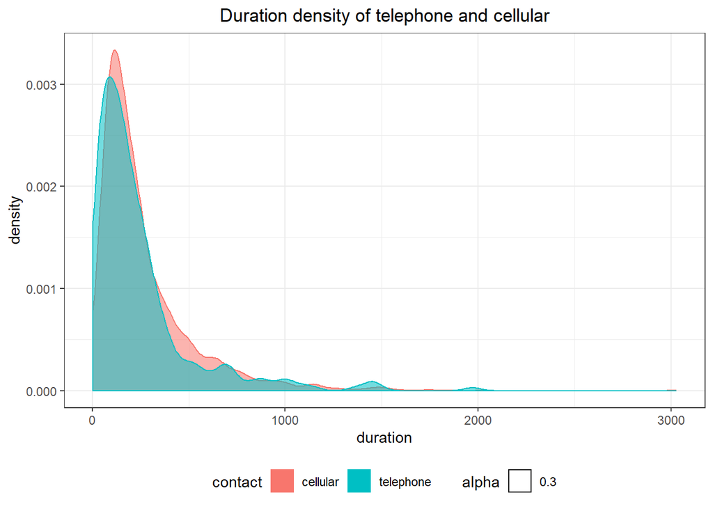

```r
ggplot(dplyr::filter(df, contact %in% c("telephone","cellular")), mapping = aes(duration, color = contact, fill = contact, alpha = 0.3)) +
  geom_density() +
  theme_bw() +
  theme(legend.position = "bottom") +
  labs(title = "Duration density of telephone and cellular") +
  theme(plot.title = element_text(hjust = 0.5))
```

The density graphs show that **both types of contact communication are similar in duration**.

# Finding #9

### Related with the last contact of the current campaign, which day and month was the most active?

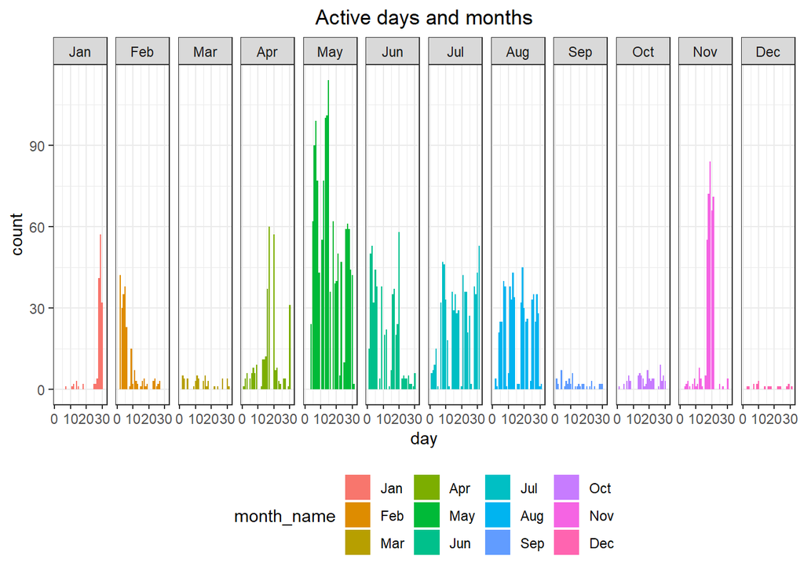

```r
firstup <- function(x) {
  substr(x, 1, 1) <- toupper(substr(x, 1, 1))
  x
}

ggplot(mutate(df, month_name = factor(firstup(as.character(month)), levels = month.abb)), mapping = aes(day, fill = month_name)) +
  geom_bar() +
  facet_grid(. ~ month_name) +
  theme_bw() +
  theme(legend.position = "bottom") +
  labs(title = "Active days and months") +
  theme(plot.title = element_text(hjust = 0.5))
```

```r
df %>% group_by(month, day) %>% summarise(count = n()) %>% arrange(desc(count)) %>% head
```

```
## # A tibble: 6 x 3
## # Groups:   month [2]
##   month   day count
##   <fct> <int> <int>
## 1 may      15   114
## 2 may      14   101
## 3 may      13   100
## 4 may       7    99
## 5 may       6    90
## 6 nov      19    84
```

From the graph, **May was the most active month** with **15 may being the most active date**.

# Finding #10

### Is there any relationship between number of contacts performed during this campaign (campaign) and before this campaign (previous) for a particular client?

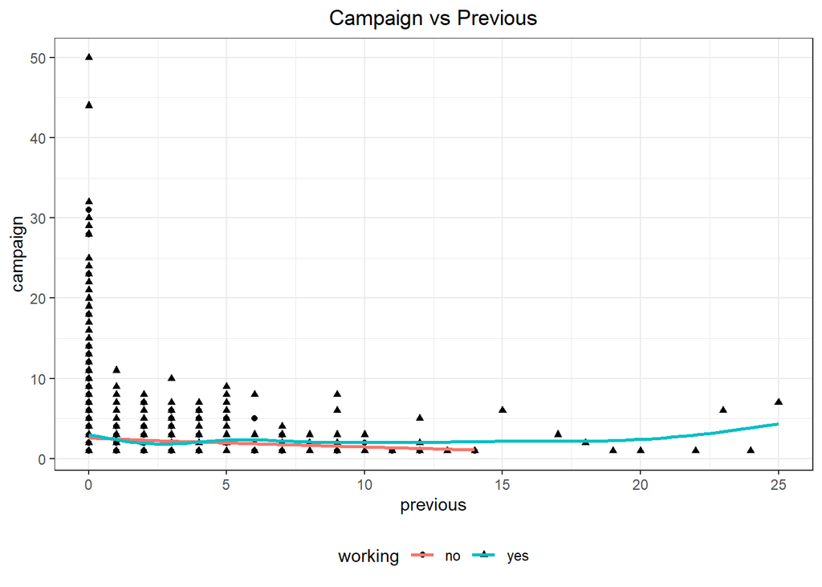

```r
ggplot(df, mapping = aes(previous, campaign, shape = working)) +
  geom_point() +
  geom_smooth(aes(color = working), se = FALSE) +
  theme_bw() +
  theme(legend.position = "bottom") +
  labs(title = "Campaign vs Previous") +
  theme(plot.title = element_text(hjust = 0.5))
## `geom_smooth()` using method = 'gam' and formula 'y ~ s(x, bs = "cs")'
```

**No clear relationship can be drawn from this scatter plot**. However, one can see that **for non-working clients, it seems that as the number of previous contacts performed increases, the number of contacts performed during this campaign decreases**.